# Language

```r
library(ggplot2)
library(dplyr)
library(tidyr)
library(RColorBrewer)
library(gridExtra)
library(rebus)
library(stringr)
library(ggmap)
setwd("c:/testR/datasets/Kaggle/world languages/")
lang_data<-read.csv("data.csv",stringsAsFactors = FALSE)
```

```r
str(lang_data)
```

```
## 'data.frame':    2722 obs. of  15 variables:
##  $ ID                         : int  1022 1023 383 335 382 405 2211 1586 1020 1943 ...
##  $ Name.in.English            : chr  "South Italian" "Sicilian" "Low Saxon" "Belarusian" ...
##  $ Name.in.French             : chr  "italien du sud" "sicilien" "bas-saxon" "biÃ©lorusse" ...
##  $ Name.in.Spanish            : chr  "napolitano-calabrÃ©s" "siciliano" "bajo sajÃ³n" "bielorruso" ...
##  $ Countries                  : chr  "Italy" "Italy" "Germany, Denmark, Netherlands, Poland, Russian Federation" "Belarus, Latvia, Lithuania, Poland, Russian Federation, Ukraine" ...
##  $ Country.codes.alpha.3      : chr  "ITA" "ITA" "DEU, DNK, NLD, POL, RUS" "BRB, LVA, LTU, POL, RUS, UKR" ...
##  $ ISO639.3.codes             : chr  "nap" "scn" "act, drt, frs, gos, nds, sdz, stl, twd, vel, wep" "bel" ...
##  $ Degree.of.endangerment     : chr  "Vulnerable" "Vulnerable" "Vulnerable" "Vulnerable" ...
##  $ Alternate.names            : chr  "Neapolitan; Neapolitan-Calabrese; Ð½ÐµÐ°Ð¿Ð¾Ð»Ð¸ÑÐ°Ð½ÑÐºÐ¸Ð¹; Ð½ÐµÐ°Ð¿Ð¾Ð»Ð¸ÑÐ°Ð½ÑÐºÐ¾-ÐºÐ°Ð»Ð°Ð±ÑÐ¸Ð¹ÑÐºÐ¸Ð¹" "" "Low German, NiedersÃ¤chsisch, Nedersaksisch, Niederdeutsch, Plattdeutsch " "" ...
##  $ Name.in.the.language       : chr  "" "" "Neddersassisch" "" ...
##  $ Number.of.speakers         : int  7500000 5000000 4800000 4000000 3500000 3500000 3000000 2713790 2600000 2300000 ...
##  $ Sources                    : chr  "" "" "" "HienadÅº Cychun: WeiÃrussisch. â Lexikon der Sprachen des europÃ¤ischen Ostens. Herausgegeben von MiloÅ¡ Okuka unter Mitwirk"| __truncated__ ...
##  $ Latitude                   : num  41 37.4 53.4 54 45.7 ...
##  $ Longitude                  : num  15.25 14.5 10.36 27.58 9.33 ...
##  $ Description.of.the.location: chr  "Campania, Lucania (Basilicata), Abruzzi (Abruzzo), Molise, northern Calabria, northern and central Apulia (Puglia), southern La"| __truncated__ "Sicily (Sicilia), southern and central Calabria and southern Apulia (Puglia); a large number of Ã©migrÃ© communiti…
```

Change the varaibles names to readale format, since it has some special characters.

```r
cnames<-c("id","name_english","name_french","name_spanish","country","country_code","iso_code","endangerment_degree","alternate_name","name_in_language","Number_of_speakers","sources","latitude","longitude","location_desc")
colnames(lang_data)<-cnames
str(lang_data)
```

```
## 'data.frame':    2722 obs. of  15 variables:
##  $ id                 : int  1022 1023 383 335 382 405 2211 1586 1020 1943 ...
##  $ name_english       : chr  "South Italian" "Sicilian" "Low Saxon" "Belarusian" ...
##  $ name_french        : chr  "italien du sud" "sicilien" "bas-saxon" "biÃ©lorusse" ...
##  $ name_spanish       : chr  "napolitano-calabrÃ©s" "siciliano" "bajo sajÃ³n" "bielorruso" ...
##  $ country            : chr  "Italy" "Italy" "Germany, Denmark, Netherlands, Poland, Russian Federation" "Belarus, Latvia, Lithuania, Poland, Russian Federation, Ukraine" ...
##  $ country_code       : chr  "ITA" "ITA" "DEU, DNK, NLD, POL, RUS" "BRB, LVA, LTU, POL, RUS, UKR" ...
##  $ iso_code           : chr  "nap" "scn" "act, drt, frs, gos, nds, sdz, stl, twd, vel, wep" "bel" ...
##  $ endangerment_degree: chr  "Vulnerable" "Vulnerable" "Vulnerable" "Vulnerable" ...
##  $ alternate_name     : chr  "Neapolitan; Neapolitan-Calabrese; Ð½ÐµÐ°Ð¿Ð¾Ð»Ð¸ÑÐ°Ð½ÑÐºÐ¸Ð¹; Ð½ÐµÐ°Ð¿Ð¾Ð»Ð¸ÑÐ°Ð½ÑÐºÐ¾-ÐºÐ°Ð»Ð°Ð±ÑÐ¸Ð¹ÑÐºÐ¸Ð¹" "" "Low German, NiedersÃ¤chsisch, Nedersaksisch, Niederdeutsch, Plattdeutsch " "" ...
##  $ name_in_language   : chr  "" "" "Neddersassisch" "" ...
##  $ Number_of_speakers : int  7500000 5000000 4800000 4000000 3500000 3500000 3000000 2713790 2600000 2300000 ...
##  $ sources            : chr  "" "" "" "HienadÅº Cychun: WeiÃrussisch. â Lexikon der Sprachen des europÃ¤ischen Ostens. Herausgegeben von MiloÅ¡ Okuka unter Mitwirk"| __truncated__ ...
##  $ latitude           : num  41 37.4 53.4 54 45.7 ...
##  $ longitude          : num  15.25 14.5 10.36 27.58 9.33 ...
##  $ location_desc      : chr  "Campania, Lucania (Basilicata), Abruzzi (Abruzzo), Molise, northern Calabria, northern and central Apulia (Puglia), southern La"| __truncated__ "Sicily (Sicilia), southern and central Calabria and southern Apulia (Puglia); a large number of Ã©migrÃ© communities" "nor…
```

```r
dim(lang_data)
```

```
## [1] 2722   15
```

## Endangerment Degree

**Vulnerable:** most children speak the language, but it may be restricted to certain domains (e.g., home) **Definitely endangered:** children no longer learn the language as a ‘mother tongue’ in the home **Severely endangered:** language is spoken by grandparents and older generations; while the parent generation may understand it, they do not speak it to children or among themselves **Critically endangered:** the youngest speakers are grandparents and older, and they speak the language partially and infrequently **Extinct:** there are no speakers left

Find out how many speakers exists under each degree, obviously extinct won’t have any speakers at all.

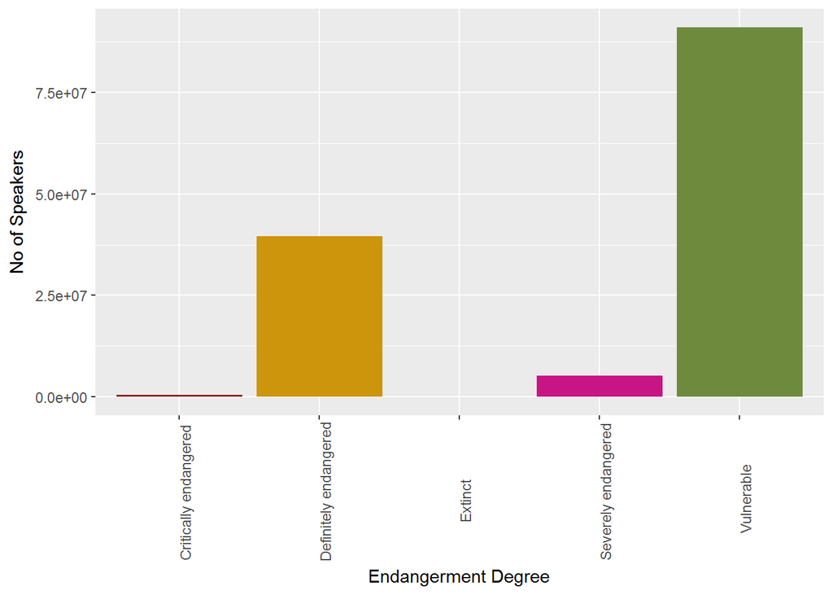

```r
lang_data %>% group_by(endangerment_degree)%>% arrange(desc(Number_of_speakers))%>%  ggplot(aes(x=factor(endangerment_degree),y=Number_of_speakers,fill=factor(endangerment_degree                                                                           )))+geom_bar(stat="identity")+theme(legend.position = "None",axis.text.x = element_text(angle=90,hjust=0.4))+labs(x="Endangerment Degree",y="No of Speakers")+scale_fill_manual(values=c("brown4","darkgoldenrod3","darkgrey","mediumvioletred","darkolivegreen4"))
```

## Languages under Extinct degree Which country has got more extinct languages

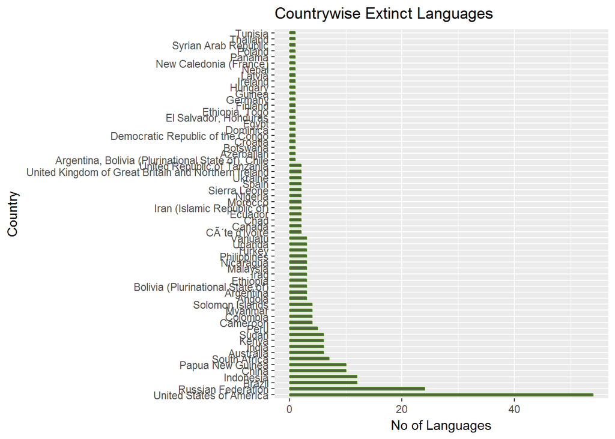

```r
lang_data %>% filter(endangerment_degree=="Extinct")%>%group_by(country)%>% summarize(n=n())%>%arrange(desc(n))%>%ggplot(aes(x=factor(country,levels=country),y=n))+geom_bar(stat="identity",width=0.4,color="chartreuse4")+coord_flip()+labs(x="Country",y="No of Languages",title="Countrywise Extinct Languages")
```

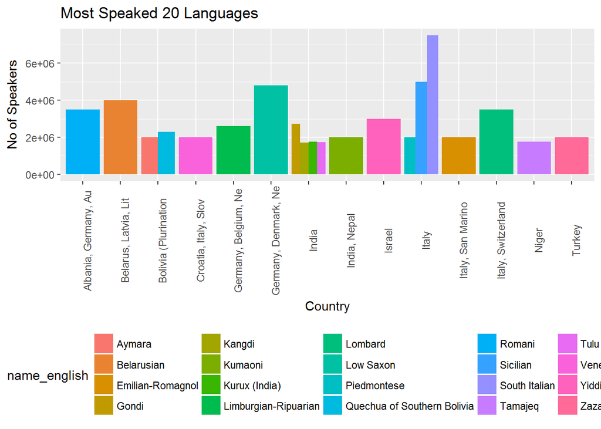

```r
most_used<-lang_data %>%  arrange(desc(Number_of_speakers))%>% head(20)
#nrow(most_used)
#lang_data$longitude[index_lon]<-0
ggplot(most_used,aes(x=str_sub(country,1,20),y=Number_of_speakers,fill=name_english))+
  geom_bar(stat="identity",position="Dodge")+ggtitle("Most Speaked 20 Languages")+theme(axis.text.x = element_text(angle=90),legend.position = "bottom")+labs(x="Country",y="No of Speakers",color="Language")
```

Find out the number of languages under endangerment degree, around **250** languages are under **Extinct** category, for which measures should be taken to preseve it.

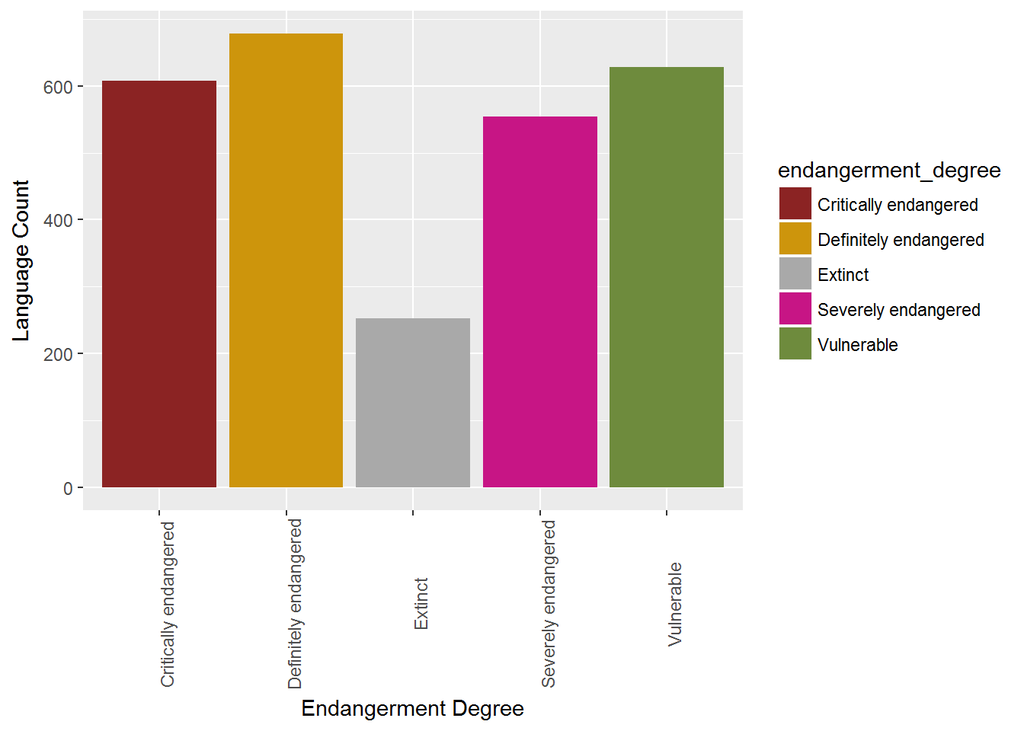

```r
degree_data<-lang_data %>% group_by(endangerment_degree) %>% summarise(lang_count=n_distinct(name_english),speakers=sum(Number_of_speakers))%>% arrange(desc(speakers))


ggplot(degree_data,aes(x=endangerment_degree,y=lang_count,fill=endangerment_degree))+geom_bar(stat="identity")+scale_fill_manual(values=c("brown4","darkgoldenrod3","darkgrey","mediumvioletred","darkolivegreen4"))+theme(axis.text.x = element_text(angle=90))+labs(x="Endangerment Degree",y="Language Count")
```

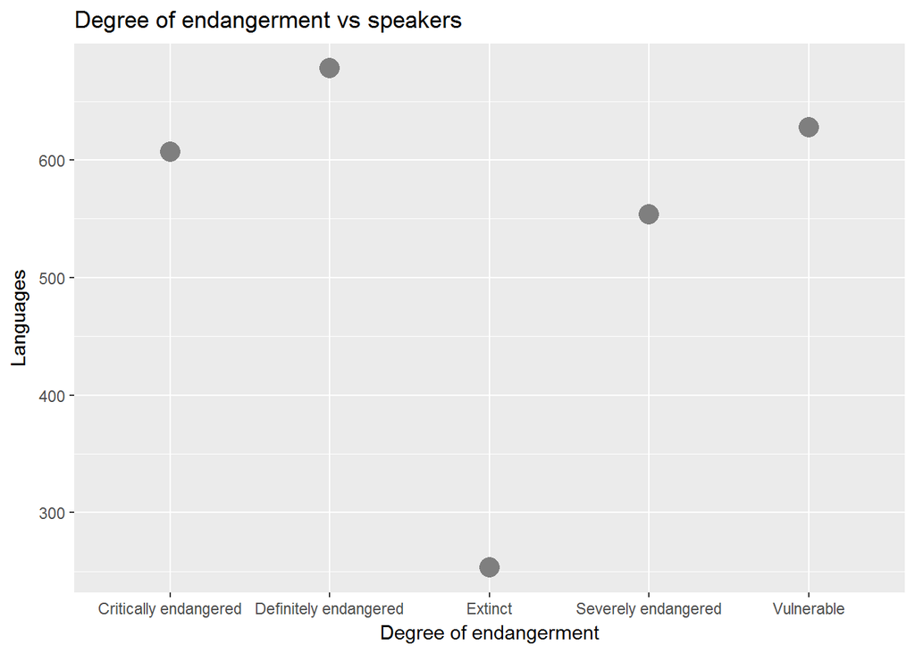

```r
ggplot(degree_data,aes(x=endangerment_degree,y=lang_count,col=speakers))+geom_point(size=5)+
  xlab("Degree of endangerment") + ylab("Languages") +
 ggtitle("Degree of endangerment vs speakers")
```

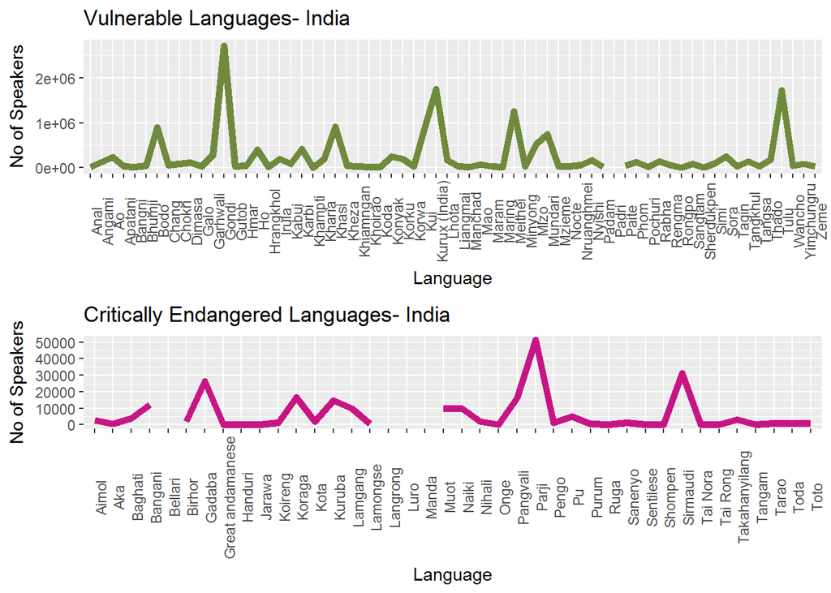

```r
g1<-lang_data%>% filter(country=="India" & endangerment_degree=="Vulnerable")%>%ggplot(aes(x=factor(name_english),y=Number_of_speakers,group=endangerment_degree,color=endangerment_degree))+geom_line(size=2,color="darkolivegreen4")+theme(axis.text.x = element_text(angle=90),legend.position = "None")+labs(x="Language",y="No of Speakers",title="Vulnerable Languages- India")

g2<-lang_data%>% filter(country=="India" & endangerment_degree=="Critically endangered")%>%ggplot(aes(x=factor(name_english),y=Number_of_speakers,group=endangerment_degree,color=endangerment_degree))+geom_line(size=2,color="mediumvioletred")+theme(axis.text.x = element_text(angle=90),legend.position = "None")+labs(x="Language",y="No of Speakers",title="Critically Endangered Languages- India")
g3<-lang_data%>% filter(country=="India" & endangerment_degree=="Definitely endangered")%>%ggplot(aes(x=factor(name_english),y=Number_of_speakers,group=endangerment_degree,color=endangerment_degree))+geom_line(size=2,color="brown4")+theme(axis.text.x = element_text(angle=90),legend.position = "None")+labs(x="Language",y="No of Speakers",title="Definitely Languages- India")
g4<-lang_data%>% filter(country=="India" & endangerment_degree=="Severely endangered")%>%ggplot(aes(x=factor(name_english),y=Number_of_speakers,group=endangerment_degree,color=endangerment_degree))+geom_line(size=2,color="darkgoldenrod3")+theme(axis.text.x = element_text(angle=90),legend.position = "None")+labs(x="Language",y="No of Speakers",title="Severely Languages- India")
grid.arrange(g1,g2,ncol=1,nrow=2)
```

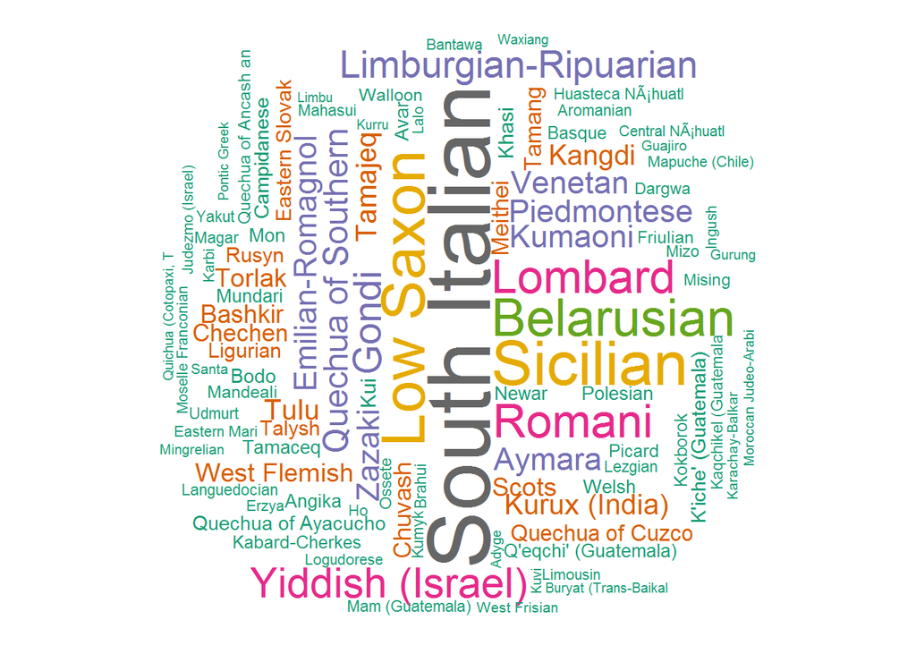

```r
l1<-lang_data %>% select(name_english,Number_of_speakers)%>% distinct()%>%arrange(desc(Number_of_speakers))%>% head(200)

library(wordcloud)

wordcloud(words = str_sub(l1$name_english,1,20), freq = l1$Number_of_speakers,
          min.freq = 80000,
          max.words=100, random.order=FALSE, rot.per=0.35,
          colors=brewer.pal(8, "Dark2"))
```

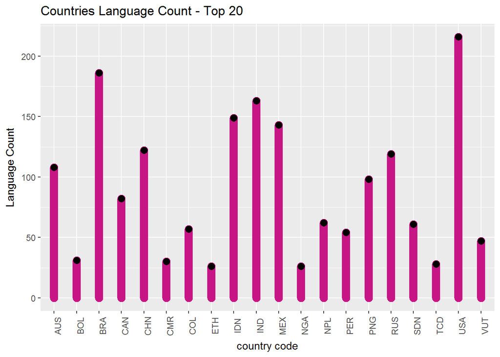

```r
patt<- ANY_CHAR %R% ANY_CHAR %R% ANY_CHAR
code<-unique(str_extract(lang_data$country_code,patt))
l2<-lang_data[lang_data$country_code %in% code,]
l2 %>% select(name_english,country_code)%>% group_by(country_code)%>%summarise(n=n())%>% arrange(desc(n))%>%head(20)%>%ggplot(aes(x=factor(country_code),y=n))+geom_area(stat="identity",alpha=0.5,color="mediumvioletred",size=4)+geom_point(color="black",size=3)+theme(axis.text.x = element_text(angle=90))+labs(x="country code",y="Language Count",title="Countries Language Count - Top 20")
```

## Mapping **extinct** languages

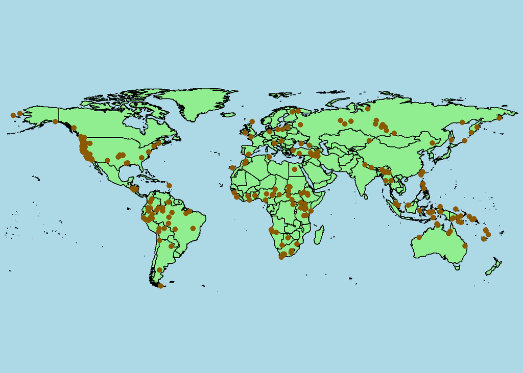

```r
elang<-lang_data%>%filter(endangerment_degree=="Extinct")
lon<-elang$longitude
lat<-elang$latitude
library(maps)
map("world", fill=TRUE, col="lightgreen", bg="lightblue", ylim=c(-60, 90), mar=c(0,0,0,0))

points(lon,lat, col="orange4", pch=16)
```

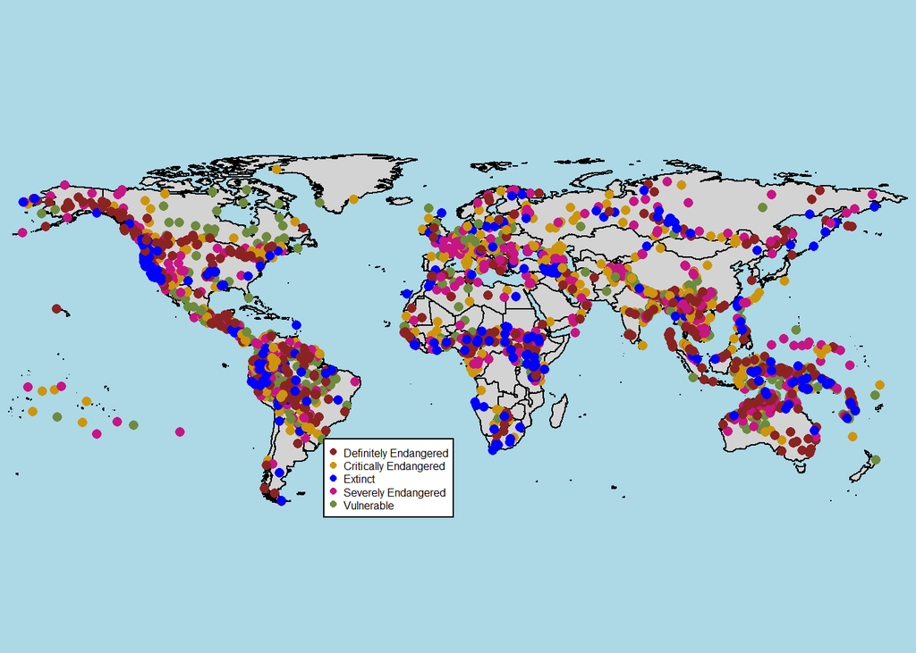

```r
#cols<-brewer.pal(n=5,name="Set1")
cols<-c("brown4","darkgoldenrod3","blue","mediumvioletred","darkolivegreen4")
cols_m1<-cols[factor(lang_data$endangerment_degree)]
map("world", fill=TRUE, col="lightgrey", bg="lightblue", ylim=c(-60, 90), mar=c(0,0,0,0))

points(lang_data$longitude,lang_data$latitude, col=cols_m1, pch=16)
legend(x=-50,y=-30,legend=paste(rep(c("Definitely Endangered","Critically Endangered","Extinct","Severely Endangered","Vulnerable"),times=1)),
                             col=rep(cols,times=1),pch=16,bty="0",cex=0.5,pt.cex=0.7)
```

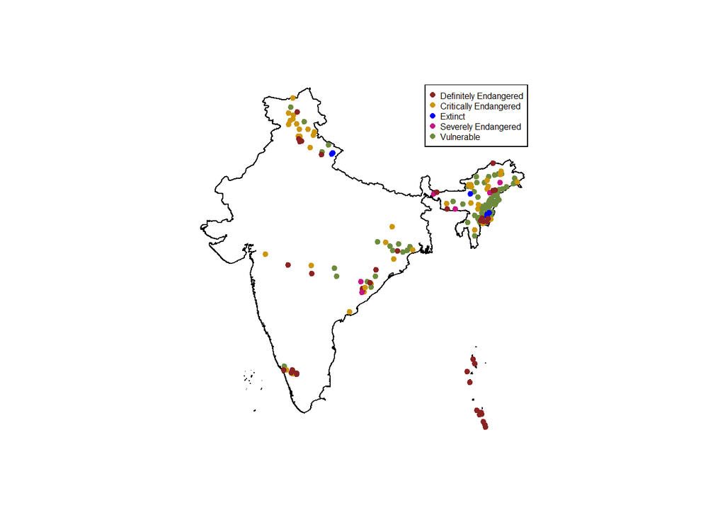

```r
library(mapdata)
elang_ind<-lang_data%>%filter(country == "India")
cols_m2<-cols[factor(elang_ind$endangerment_degree)]

map("worldHires","India",  col="white", fill=TRUE)
points(elang_ind$longitude, elang_ind$latitude, pch=19, col=cols_m2, cex=0.7)
legend("topright",legend=paste(rep(c("Definitely Endangered","Critically Endangered","Extinct","Severely Endangered","Vulnerable"),times=1)),
                             col=rep(cols,times=1),pch=16,bty="0",cex=0.5,pt.cex=0.7)
```

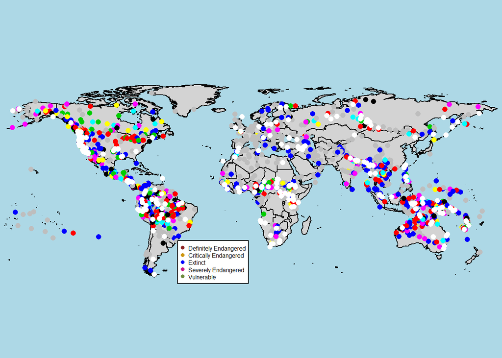

```r
#cols<-brewer.pal(n=5,name="Set1")
cols<-c("brown4","darkgoldenrod3","blue","mediumvioletred","darkolivegreen4")
cols_m1<-cols[factor(lang_data$endangerment_degree)]
map("world", fill=TRUE, col="lightgrey", bg="lightblue", ylim=c(-60, 90), mar=c(0,0,0,0))

points(lang_data$longitude,lang_data$latitude, col=lang_data$Number_of_speakers, pch=16)
legend(x=-50,y=-30,legend=paste(rep(c("Definitely Endangered","Critically Endangered","Extinct","Severely Endangered","Vulnerable"),times=1)),
                             col=rep(cols,times=1),pch=16,bty="0",cex=0.5,pt.cex=0.7)
```

##Mapping Number of Speakers

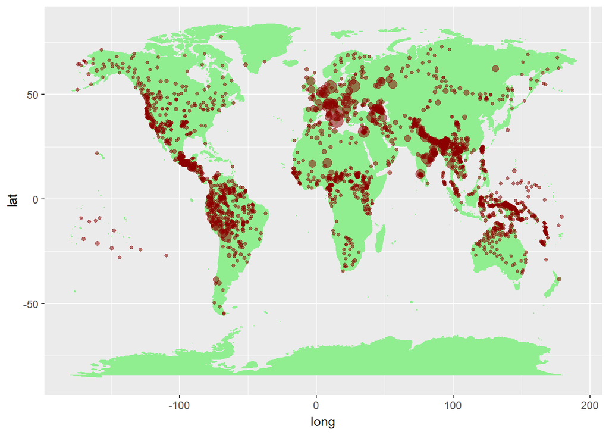

```r
mapWorld <- NULL
mp <- borders("world", colour="lightgreen", fill="lightgreen",bg="skyblue")
ggplot() +   mp + geom_point(aes(x = longitude, y = latitude, size =Number_of_speakers ),data=lang_data, alpha = 0.5,color="red4")+ scale_fill_continuous(guide = guide_legend()) + theme(legend.position="topright",plot.background=element_blank())
```

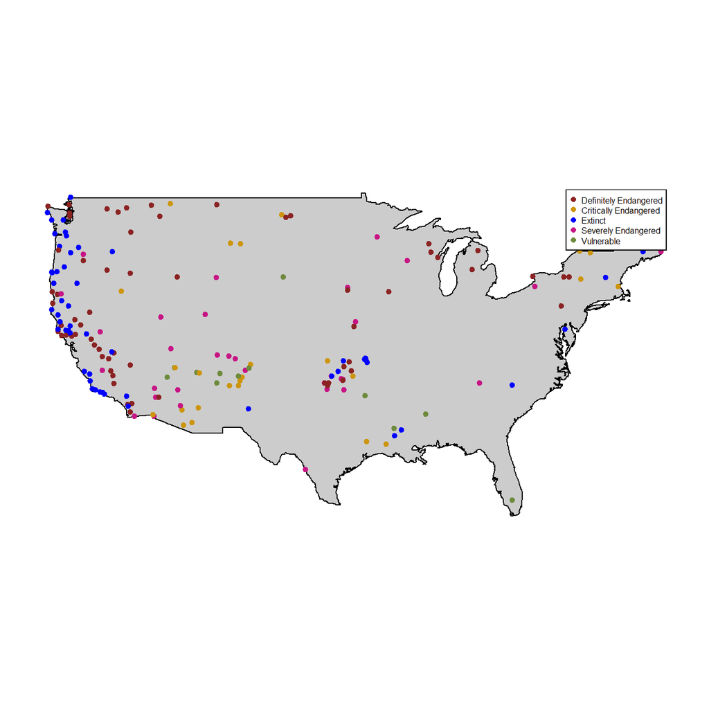

```r
elang_usa<-lang_data%>%filter(country == "United States of America")
cols_m2<-cols[factor(elang_usa$endangerment_degree)]

#map("worldHires","usa",  col="white", fill=TRUE,  ylim=c(0,90))
map(database= "usa", col="grey80", fill=TRUE)
points(elang_usa$longitude, elang_usa$latitude, pch=19, col=cols_m2, cex=0.7)
legend("topright",legend=paste(rep(c("Definitely Endangered","Critically Endangered","Extinct","Severely Endangered","Vulnerable"),times=1)),
                             col=rep(cols,times=1),pch=16,bty="0",cex=0.5,pt.cex=0.7)
```